# Statistical Learning: Final Project

Mike Baietto, Dan Malee, Gerard Martinez, and Tony Galvan

West

10/29/2018

# Final Project

## Description

The goal of this project is to identify and explore interesting aspects of data in a real-world context, provide extensive explanations about each step, and report on our analysis of the results.

This write-up will consist of the following sections:

1. Exploratory Data Analysis (EDA)
2. Preprocessing
3. Initial Models
4. Model Optimization
5. Figures & Conclusion

## Read In spambase.data file

```r
#Start Fresh
rm(list=ls())
```

```r
#Load libraries
library(tidyverse)
library(plm)
library(tidyr)
library(ggplot2)
library(scales)
library(readstata13)
library(corrplot)
library(reshape)
library(dplyr)
library(corrplot)
library(gridExtra)
library(rpart)
library(partykit)
library(caret)
library(mlbench)
library(tidyverse)
library(rminer)
library(randomForest)
library(reshape2)
library(MASS)
library(e1071)
library(wsrf)
library(kernlab)
```

# EXPLORATORY DATA ANALYSIS (EDA) SECTION

## LOAD THE DATA

```r
# set working directory and import data
#setwd(dirname(rstudioapi::getSourceEditorContext()$path))
spamdata <- read.csv("spambase.data", header=FALSE)
dim(spamdata)
```

```
## [1] 4601   58
```

The “spambase” data set consists of 4601 observations with 58 variables. Let’s take a closer look at the data.

```r
glimpse(spamdata)
```

```
## Observations: 4,601
## Variables: 58
## $ V1  <dbl> 0.00, 0.21, 0.06, 0.00, 0.00, 0.00, 0.00, 0.00, 0.15, 0.06...
## $ V2  <dbl> 0.64, 0.28, 0.00, 0.00, 0.00, 0.00, 0.00, 0.00, 0.00, 0.12...
## $ V3  <dbl> 0.64, 0.50, 0.71, 0.00, 0.00, 0.00, 0.00, 0.00, 0.46, 0.77...
## $ V4  <dbl> 0, 0, 0, 0, 0, 0, 0, 0, 0, 0, 0, 0, 0, 0, 0, 0, 0, 0, 0, 0...
## $ V5  <dbl> 0.32, 0.14, 1.23, 0.63, 0.63, 1.85, 1.92, 1.88, 0.61, 0.19...
## $ V6  <dbl> 0.00, 0.28, 0.19, 0.00, 0.00, 0.00, 0.00, 0.00, 0.00, 0.32...
## $ V7  <dbl> 0.00, 0.21, 0.19, 0.31, 0.31, 0.00, 0.00, 0.00, 0.30, 0.38...
## $ V8  <dbl> 0.00, 0.07, 0.12, 0.63, 0.63, 1.85, 0.00, 1.88, 0.00, 0.00...
## $ V9  <dbl> 0.00, 0.00, 0.64, 0.31, 0.31, 0.00, 0.00, 0.00, 0.92, 0.06...
## $ V10 <dbl> 0.00, 0.94, 0.25, 0.63, 0.63, 0.00, 0.64, 0.00, 0.76, 0.00...
## $ V11 <dbl> 0.00, 0.21, 0.38, 0.31, 0.31, 0.00, 0.96, 0.00, 0.76, 0.00...
## $ V12 <dbl> 0.64, 0.79, 0.45, 0.31, 0.31, 0.00, 1.28, 0.00, 0.92, 0.64...
## $ V13 <dbl> 0.00, 0.65, 0.12, 0.31, 0.31, 0.00, 0.00, 0.00, 0.00, 0.25...
```

[output cut: 45 more lines]

Let’s see if we have any missing data.

```r
# Find NA per Column
if (sum(is.na(spamdata)) == 0) {
  print(paste("The count of NA in dataset =", sum(is.na(spamdata))))
} else {
  cnt <- ncol(spamdata)
  for (i in 1:cnt) {
    print(colnames(spamdata)[i])
    print(sum(is.na(spamdata[,i])))
  }
}
```

```
## [1] "The count of NA in dataset = 0"
```

It is nice that we do not have to deal with missing data.

Next, we have to add names for our variables, correct a few variable data types, and move the response variable, “spam” to the first column.

```r
#create a list of variable names
newnames <- c("freq_make", "freq_address", "freq_all", "freq_3d", "freq_our", "freq_over", "freq_remove", "freq_internet",
              "freq_order", "freq_mail", "freq_receive", "freq_will", "freq_people", "freq_report", "freq_addresses", "freq_free",
              "freq_business", "freq_email", "freq_you", "freq_credit", "freq_your", "freq_font", "freq_000", "freq_money",
              "freq_hp", "freq_hpl", "freq_george", "freq_650", "freq_lab", "freq_labs", "freq_telnet", "freq_857",
              "freq_data", "freq_415", "freq_85", "freq_technology", "freq_1999", "freq_parts", "freq_pm", "freq_direct",
              "freq_vcs", "freq_meeting", "freq_original", "freq_project", "freq_re", "freq_edu", "freq_table", "freq_conference",
              "freq_semicolon", "freq_parentheses", "freq_bracket", "freq_exclamation_point", "freq_dollar_sign", "freq_pound_sign",
              "caps_len_average", "caps_len_longest", "caps_len_total", "spam")

# set the variable names
names(spamdata) <- newnames

# tidy the data
spamdata$caps_len_longest <- as.double(spamdata$caps_len_longest)
spamdata$caps_len_total <- as.double(spamdata$caps_len_total)
spamdata <- spamdata %>% dplyr::select(spam,everything())
spamdata$spam <- as.factor(ifelse(spamdata$spam==1,"Y","N"))
```

Let’s make sure our variables look better now.

```r
glimpse(spamdata)
```

```
## Observations: 4,601
## Variables: 58
## $ spam                   <fct> Y, Y, Y, Y, Y, Y, Y, Y, Y, Y, Y, Y, Y, ...
## $ freq_make              <dbl> 0.00, 0.21, 0.06, 0.00, 0.00, 0.00, 0.0...
## $ freq_address           <dbl> 0.64, 0.28, 0.00, 0.00, 0.00, 0.00, 0.0...
## $ freq_all               <dbl> 0.64, 0.50, 0.71, 0.00, 0.00, 0.00, 0.0...
## $ freq_3d                <dbl> 0, 0, 0, 0, 0, 0, 0, 0, 0, 0, 0, 0, 0, ...
## $ freq_our               <dbl> 0.32, 0.14, 1.23, 0.63, 0.63, 1.85, 1.9...
## $ freq_over              <dbl> 0.00, 0.28, 0.19, 0.00, 0.00, 0.00, 0.0...
## $ freq_remove            <dbl> 0.00, 0.21, 0.19, 0.31, 0.31, 0.00, 0.0...
## $ freq_internet          <dbl> 0.00, 0.07, 0.12, 0.63, 0.63, 1.85, 0.0...
## $ freq_order             <dbl> 0.00, 0.00, 0.64, 0.31, 0.31, 0.00, 0.0...
## $ freq_mail              <dbl> 0.00, 0.94, 0.25, 0.63, 0.63, 0.00, 0.6...
## $ freq_receive           <dbl> 0.00, 0.21, 0.38, 0.31, 0.31, 0.00, 0.9...
## $ freq_will              <dbl> 0.64, 0.79, 0.45, 0.31, 0.31, 0.00, 1.2...
```

[output cut: 45 more lines]

Let’s get a clean, condensed look at the variable names.

```r
names(spamdata)
```

```
##  [1] "spam"                   "freq_make"
##  [3] "freq_address"           "freq_all"
##  [5] "freq_3d"                "freq_our"
##  [7] "freq_over"              "freq_remove"
##  [9] "freq_internet"          "freq_order"
## [11] "freq_mail"              "freq_receive"
## [13] "freq_will"              "freq_people"
## [15] "freq_report"            "freq_addresses"
## [17] "freq_free"              "freq_business"
## [19] "freq_email"             "freq_you"
## [21] "freq_credit"            "freq_your"
## [23] "freq_font"              "freq_000"
## [25] "freq_money"             "freq_hp"
## [27] "freq_hpl"               "freq_george"
## [29] "freq_650"               "freq_lab"
## [31] "freq_labs"              "freq_telnet"
## [33] "freq_857"               "freq_data"
## [35] "freq_415"               "freq_85"
## [37] "freq_technology"        "freq_1999"
## [39] "freq_parts"             "freq_pm"
## [41] "freq_direct"            "freq_vcs"
## [43] "freq_meeting"           "freq_original"
## [45] "freq_project"           "freq_re"
## [47] "freq_edu"               "freq_table"
## [49] "freq_conference"        "freq_semicolon"
## [51] "freq_parentheses"       "freq_bracket"
## [53] "freq_exclamation_point" "freq_dollar_sign"
## [55] "freq_pound_sign"        "caps_len_average"
## [57] "caps_len_longest"       "caps_len_total"
```

Now, we can look at a table of values for the response variable.

```r
table(spamdata$spam)
```

```
##
##    N    Y
## 2788 1813
```

We have 1813 observations that are classified as “spam” and 2788 observations that are classified as not “spam”.

Next, let’s check the data for outliers.

```r
#manually look for outliers
# standard deviation methods
# 2 SD beyond the mean covers 95% of a normally distributed variable
# 3 SD +/- the mean covers 99.7% of a normally distributed variable

for (i in 2:ncol(spamdata)){
  temp <- spamdata[,i] > (mean(spamdata[,i] + 3*sd(spamdata[,i])))
  temp2 <- round(table(temp)[2]/nrow(spamdata) * 100,2)
  temp2
  print(paste(temp2, "pecent of the", names(spamdata)[i], "data exceeds 3 SD from the mean"))
}
```

```
## [1] "1.96 pecent of the freq_make data exceeds 3 SD from the mean"
## [1] "0.93 pecent of the freq_address data exceeds 3 SD from the mean"
## [1] "2.04 pecent of the freq_all data exceeds 3 SD from the mean"
## [1] "0.28 pecent of the freq_3d data exceeds 3 SD from the mean"
## [1] "1.76 pecent of the freq_our data exceeds 3 SD from the mean"
## [1] "2.26 pecent of the freq_over data exceeds 3 SD from the mean"
## [1] "2.15 pecent of the freq_remove data exceeds 3 SD from the mean"
## [1] "1.67 pecent of the freq_internet data exceeds 3 SD from the mean"
## [1] "2.46 pecent of the freq_order data exceeds 3 SD from the mean"
## [1] "1.61 pecent of the freq_mail data exceeds 3 SD from the mean"
## [1] "2.17 pecent of the freq_receive data exceeds 3 SD from the mean"
## [1] "2.22 pecent of the freq_will data exceeds 3 SD from the mean"
## [1] "1.93 pecent of the freq_people data exceeds 3 SD from the mean"
## [1] "2.3 pecent of the freq_report data exceeds 3 SD from the mean"
## [1] "2.15 pecent of the freq_addresses data exceeds 3 SD from the mean"
```

[output cut: 42 more lines]

```r
#sapply(dat_num, function(d) (d > (mean(d) + 2*sd(d))))
#sapply(dat_num, function(d) which(d > (mean(d) + 2*sd(d))))
```

There are some outliers in all of the variable, but nothing seems too alarming.

## HISTOGRAMS

Let’s create histograms for the unscaled predictor variables

```r
# Create Histograms
for (i in 2:ncol(spamdata)){
  assign(paste0("h", i), ggplot(data= spamdata, aes_string(colnames(spamdata)[i], fill=spamdata$spam)) + geom_histogram() + #ggtitle(names(spamdata[i])) +
  theme_bw()+ theme(plot.title = element_text(hjust = 0.5)))
}
```

```r
grid.arrange(h2, h3, h4, h5, h6, h7, h8, h9, h10, h11,
             h12, h13, h14, h15, h16, h17, h18, h19, h20, h21,
             h22, h23, h24, h25, h26, h27, h28, h29, h30, h31,
             h32, h33, h34, h35, h36, h37, h38, h39, h40, h41,
             h42, h43, h44, h45, h46, h47, h48, h49, h50, h51,
             h52, h53, h54, h55, h56, h57, h58,
             ncol=2,
             top=textGrob(expression(bold(underline("Histograms"))),
                          gp=gpar(fontsize=20,font=3)))
```

[figure not shown]

Based on these histograms, it seems clear that some variables are more important than others.

## BOX PLOTS

Create box plots for the predictor variables.

```r
# Create Boxplots
for (i in 2:ncol(spamdata)){
  assign(paste0("p", i),
         ggplot( data = spamdata,
                 aes_string(x = names(spamdata[1]),
                     y = names(spamdata[i]),
                               fill = spamdata$spam)) +
                 geom_boxplot() + coord_flip() +
                   theme_bw()+
                   theme(plot.title = element_text(hjust = 1.5)))
}
```

```r
grid.arrange(p2, p3, p4, p5, p6, p7, p8, p9, p10, p11,
             p12, p13, p14, p15, p16, p17, p18, p19, p20, p21,
             p22, p23, p24, p25, p26, p27, p28, p29, p30, p31,
             p32, p33, p34, p35, p36, p37, p38, p39, p40, p41,
             p42, p43, p44, p45, p46, p47, p48, p49, p50, p51,
             p52, p53, p54, p55, p56, p57, p58,
             ncol=2,
             top=textGrob(expression(bold(underline("Boxplots"))),
                          gp=gpar(fontsize=20,font=3)))
```

[figure not shown]

# PREPROCESSING SECTION

Let’s rescale the data so that all of the values are between 0 and 1.

```r
#Rescale the numeric data
spamdata2 <- spamdata
rescale_x <- function(x){(x-min(x))/(max(x)-min(x))}

for (i in 2:ncol(spamdata)){
spamdata2[[i]] <- rescale_x(spamdata[[i]])
}
```

We will do a summary of the scaled data to make sure the scaling function worked as expected.

```r
summary(spamdata2)
```

```
##  spam       freq_make        freq_address        freq_all
##  N:2788   Min.   :0.00000   Min.   :0.00000   Min.   :0.00000
##  Y:1813   1st Qu.:0.00000   1st Qu.:0.00000   1st Qu.:0.00000
##           Median :0.00000   Median :0.00000   Median :0.00000
##           Mean   :0.02303   Mean   :0.01492   Mean   :0.05503
##           3rd Qu.:0.00000   3rd Qu.:0.00000   3rd Qu.:0.08235
##           Max.   :1.00000   Max.   :1.00000   Max.   :1.00000
##     freq_3d            freq_our         freq_over        freq_remove
##  Min.   :0.000000   Min.   :0.00000   Min.   :0.00000   Min.   :0.00000
##  1st Qu.:0.000000   1st Qu.:0.00000   1st Qu.:0.00000   1st Qu.:0.00000
##  Median :0.000000   Median :0.00000   Median :0.00000   Median :0.00000
##  Mean   :0.001528   Mean   :0.03122   Mean   :0.01631   Mean   :0.01571
##  3rd Qu.:0.000000   3rd Qu.:0.03800   3rd Qu.:0.00000   3rd Qu.:0.00000
##  Max.   :1.000000   Max.   :1.00000   Max.   :1.00000   Max.   :1.00000
##  freq_internet        freq_order        freq_mail         freq_receive
##  Min.   :0.000000   Min.   :0.00000   Min.   :0.000000   Min.   :0.00000
##  1st Qu.:0.000000   1st Qu.:0.00000   1st Qu.:0.000000   1st Qu.:0.00000
##  Median :0.000000   Median :0.00000   Median :0.000000   Median :0.00000
##  Mean   :0.009477   Mean   :0.01712   Mean   :0.013169   Mean   :0.02292
##  3rd Qu.:0.000000   3rd Qu.:0.00000   3rd Qu.:0.008801   3rd Qu.:0.00000
##  Max.   :1.000000   Max.   :1.00000   Max.   :1.000000   Max.   :1.00000
##    freq_will        freq_people       freq_report       freq_addresses
##  Min.   :0.00000   Min.   :0.00000   Min.   :0.000000   Min.   :0.00000
##  1st Qu.:0.00000   1st Qu.:0.00000   1st Qu.:0.000000   1st Qu.:0.00000
##  Median :0.01034   Median :0.00000   Median :0.000000   Median :0.00000
##  Mean   :0.05602   Mean   :0.01692   Mean   :0.005863   Mean   :0.01116
##  3rd Qu.:0.08273   3rd Qu.:0.00000   3rd Qu.:0.000000   3rd Qu.:0.00000
##  Max.   :1.00000   Max.   :1.00000   Max.   :1.000000   Max.   :1.00000
##    freq_free       freq_business       freq_email         freq_you
##  Min.   :0.00000   Min.   :0.00000   Min.   :0.00000   Min.   :0.00000
##  1st Qu.:0.00000   1st Qu.:0.00000   1st Qu.:0.00000   1st Qu.:0.00000
##  Median :0.00000   Median :0.00000   Median :0.00000   Median :0.06987
##  Mean   :0.01244   Mean   :0.01997   Mean   :0.02032   Mean   :0.08865
##  3rd Qu.:0.00500   3rd Qu.:0.00000   3rd Qu.:0.00000   3rd Qu.:0.14080
##  Max.   :1.00000   Max.   :1.00000   Max.   :1.00000   Max.   :1.00000
##   freq_credit         freq_your         freq_font           freq_000
##  Min.   :0.000000   Min.   :0.00000   Min.   :0.000000   Min.   :0.00000
##  1st Qu.:0.000000   1st Qu.:0.00000   1st Qu.:0.000000   1st Qu.:0.00000
##  Median :0.000000   Median :0.01980   Median :0.000000   Median :0.00000
##  Mean   :0.004707   Mean   :0.07289   Mean   :0.007088   Mean   :0.01865
```

[output cut: 57 more lines]

```
##  Max.   :1.000000   Max.   :1.000000   Max.   :1.00000
##  freq_exclamation_point freq_dollar_sign   freq_pound_sign
##  Min.   :0.000000       Min.   :0.000000   Min.   :0.000000
##  1st Qu.:0.000000       1st Qu.:0.000000   1st Qu.:0.000000
##  Median :0.000000       Median :0.000000   Median :0.000000
##  Mean   :0.008285       Mean   :0.012629   Mean   :0.002231
##  3rd Qu.:0.009699       3rd Qu.:0.008662   3rd Qu.:0.000000
##  Max.   :1.000000       Max.   :1.000000   Max.   :1.000000
##  caps_len_average    caps_len_longest    caps_len_total
##  Min.   :0.0000000   Min.   :0.0000000   Min.   :0.000000
##  1st Qu.:0.0005338   1st Qu.:0.0005006   1st Qu.:0.002146
##  Median :0.0011584   Median :0.0014017   Median :0.005934
##  Mean   :0.0038053   Mean   :0.0051234   Mean   :0.017821
##  3rd Qu.:0.0024567   3rd Qu.:0.0042050   3rd Qu.:0.016730
##  Max.   :1.0000000   Max.   :1.0000000   Max.   :1.000000
```

The scaling function worked. Let’s replace spamdata with the scaled spamdata2

```r
spamdata_unscaled <- spamdata
spamdata <- spamdata2
```

# INITIAL MODELS SECTION

Define our constants

```r
SEED <- 0 # random seed
REPS <- 50 # training replications
RATIO <- 0.6 # train-test split ratio
NTREE <- 100 # number of trees
```

Define function for the common training tasks.

```r
###########################################################
# Generic wrapper function for training and prediction
#
# @param name
#     name of the model e.g. "Decision Tree"
# @param build_model
#     function to perform the model-specific training
#     e.g. build_model <- function(data) {
#              return(rpart(Y ~ ., data = data))
#          }
#
# @param split_ratio
#     train to test split ratio e.g. 0.75
#
# @param predict_call
#     variable to control how predict is called
#
# @returns
#     list containing the error % for each rep and the
#     model for each rep
#
###########################################################

train_wrapper <- function(name,
                          build_model,
                          split_ratio = 0.6,
                          predict_call = 1) {
  # set random seed to use same data splits
  set.seed(SEED)

  # vector to store error for each repetition
  errors <- rep(0, REPS)

  # vector to store models for each repetition
  models <- vector(mode = "list", length = REPS)

  # vector to store yhat predictions for each repetition
  yhats <- vector(mode = "list", length = REPS)

  # vector to store test sets
  tests <- vector(mode = "list", length = REPS)

  for (r in 1:length(errors)) {
    # split data for train and test
    id = holdout(spamdata$spam, ratio=split_ratio, mode='stratified')
    train <- spamdata[id$tr,]
    test <- spamdata[id$ts,]
    tests[[r]] <- test

    # build model on training set
    model <- build_model(train)

    # store model
    models[[r]] <- model

    # predict on test set
    yhat <- switch (predict_call,
                    predict(model, test %>% dplyr::select(-spam), type = 'class'),
                    predict(model, test %>% dplyr::select(-spam)),
                    predict(model, test %>% dplyr::select(-spam))$class)

    # store predictions
    yhats[[r]] <- yhat

    # store error
    errors[r] <- mean(yhat != test$spam)

    # print progress
    cat(name, "[rep]:", r, "[error]:", errors[r], "\n")
  }

  # print confusion matrix for most accurate model
  index <- which.min(errors)
  print(confusionMatrix(table(yhats[[index]], tests[[index]]$spam)))

  return(list("errors" = errors, "models" = models))
}
```

### Regular Trees

```r
build_regular_tree <- function(training_data) {
  rpart(spam ~ ., data = training_data)
}

regular_tree_errors <- train_wrapper("Regular Trees", build_regular_tree)
```

```r
#store regular tree error data as RData files
save(regular_tree_errors, file='regular_tree_errors.rdata')
```

### Bagged Trees

Use all variables at each split (mtry = p where p = number of predictors).

```r
build_bagged_tree <- function(training_data) {
  model <- randomForest(spam ~ .,
                        data = training_data,
                        mtry = ncol(training_data) - 1,
                        ntree = NTREE)
  return(model)
}

bagged_tree_errors <- train_wrapper("Bagged Trees", build_bagged_tree)
```

```r
#store bagged tree error data as RData files
save(bagged_tree_errors, file='bagged_tree_errors.rdata')
```

### Random Forest

Use random subset of variables at each split (mtry = square root of p).

```r
build_rf <- function(training_data) {
  model <- randomForest(spam ~ .,
                        data = training_data,
                        mtry = sqrt(ncol(training_data) - 1),
                        ntree = NTREE)
  return(model)
}

rf_errors <- train_wrapper("Random Forest", build_rf)
```

```r
#store random forest error data as RData files
save(rf_errors, file='rf_errors.rdata')
```

### Weighted Random Forest

Note: the selected weights were chosen through trial and error, thus may be overfitted to this particular random seed.

```r
build_weighted_rf <- function(training_data) {
  model <- randomForest(spam ~ .,
                        data = training_data,
                        ntree = NTREE,
                        classwt = c(0.3, 0.8))
  return(model)
}

weighted_rf_errors <- train_wrapper("Weighted Random Forest", build_weighted_rf)
```

```r
#store weighted random forest error data as RData files
save(weighted_rf_errors, file='weighted_rf_errors.rdata')
```

### Balanced Random Forest

Use under/down sampling based on size of minority class.

```r
# minority class is 'Y'
build_balanced_rf <- function(training_data) {
  minority_class_size <- sum(spamdata$spam=='Y') # min(table(training_data$spam))

  model <- randomForest(spam ~ .,
                        data = training_data,
                        ntree = NTREE,
                        sampsize = minority_class_size)
  return(model)
}

balanced_rf_errors <- train_wrapper("Balanced Random Forest", build_balanced_rf)
```

```r
#store balanced random forest error data as RData files
save(balanced_rf_errors, file='balanced_rf_errors.rdata')
```

### LDA

```r
build_lda <- function(training_data) {
  model <- lda(spam ~ ., data = training_data)
  return(model)
}

lda_errors <- train_wrapper("LDA",
                            build_lda,
                            split_ratio = RATIO,
                            predict_call = 3)$errors
```

```r
#store LDA error data as RData files
save(lda_errors, file='lda_errors.rdata')
```

### C-SVM

```r
build_csvm <- function(training_data) {
  model <- svm(spam ~ ., data = training_data, type = "C-classification")
  return(model)
}

csvm_errors <- train_wrapper("C-SVM",
                             build_csvm,
                             split_ratio = RATIO)$errors
```

```r
#store C-SVM error data as RData files
save(csvm_errors, file='csvm_errors.rdata')
```

### nu-SVM

```r
build_nusvm <- function(training_data) {
  model <- svm(spam ~ ., data = training_data, type = "nu-classification")
  return(model)
}

nusvm_errors <- train_wrapper("nu-SVM",
                              build_nusvm,
                              split_ratio = RATIO)$errors
```

```r
#store C-SVM error data as RData files
save(nusvm_errors, file='nusvm_errors.rdata')
```

```r
#load all of the error data
load(file='regular_tree_errors.rdata')
load(file='bagged_tree_errors.rdata')
load(file='rf_errors.rdata')
load(file='weighted_rf_errors.rdata')
load(file='balanced_rf_errors.rdata')
load(file='lda_errors.rdata')
load(file='csvm_errors.rdata')
load(file='nusvm_errors.rdata')
```

## Compare Results

Combine error results into comparative boxplot.

```r
# aggregate to data frame
combined_errors <- as.tibble(data.frame(
  Regular = regular_tree_errors$errors,
  Bagged = bagged_tree_errors$errors,
  RF = rf_errors$errors,
  Weighted_RF = weighted_rf_errors$errors,
  Balanced_RF = balanced_rf_errors$errors,
  LDA = lda_errors,
  CSVM = csvm_errors,
  NUSVM = nusvm_errors))
```

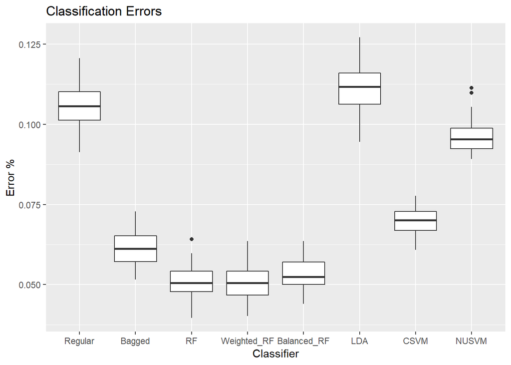

```r
# plot errors
combined_errors %>%
  melt(measure.vars = c("Regular", "Bagged", "RF", "Weighted_RF", "Balanced_RF", "LDA", "CSVM",
                        "NUSVM")) %>%
  ggplot(aes(x = variable, y = value)) + geom_boxplot() + ggtitle("Classification Errors") +
  xlab("Classifier") + ylab("Error %")
```

As we can see from the above boxplots, we have Weighted Random Forest as our best performing model, with a very small advantage over a regular Random Forest. I believe there may be some room for optimization in our models, so we will attempt optimization for both the Weighted and regular Random Forest. We will also attempt optimization for the C-SVM model just so we can see if optimization impacts support vector machine model accuracy significantly.

# MODEL OPTIMIZATION SECTION

## RANDOMFOREST OPMTIMIZATION

Try to optimize the RandomForest model using tuneLength from the caret package. As FYI, this tuning model will take about 5 - 10 minutes to run.

```r
# set control
control <- trainControl(method = 'cv', number = 5)
# retrain the model
RF_tune_model <- train(spam ~ ., data = spamdata, method = 'rf', trControl = control,
                       tuneLength = 5)
```

```r
#store the tuned random forest model data
save(RF_tune_model, file='RF_tune_model.rdata')
```

```r
#load the tuned random forest model data
load(file='RF_tune_model.rdata')
```

```r
# summarize the model
print(RF_tune_model)
```

```
## Random Forest
##
## 4601 samples
##   57 predictor
##    2 classes: 'N', 'Y'
##
## No pre-processing
## Resampling: Cross-Validated (5 fold)
## Summary of sample sizes: 3680, 3681, 3682, 3681, 3680
## Resampling results across tuning parameters:
##
##   mtry  Accuracy   Kappa
##    2    0.9426179  0.8786202
##   15    0.9502259  0.8952354
##   29    0.9484877  0.8917584
##   43    0.9447925  0.8839576
##   57    0.9450104  0.8844086
##
## Accuracy was used to select the optimal model using the largest value.
## The final value used for the model was mtry = 15.
```

```r
# calculate accuracy of the 'regular' random forest run earlier
mean(rf_errors$errors)
```

```
## [1] 0.051
```

```r
1 - mean(rf_errors$errors)
```

```
## [1] 0.949
```

## WEIGHTED RANDOMFOREST OPMTIMIZATION

Try to optimize the Weighted RandomForest model using tuneLength from the caret package, using the method ‘wsrf’ for Weighted Subspace Random Forest. As FYI, the weighted RF tuning model will take about 20 - 40 minutes to run.

```r
# set control
control <- trainControl(method = 'cv', number = 5)
# retrain the model
Weight_RF_tune_model <- train(spam ~ ., data = spamdata, method = 'wsrf', trControl = control,
                       tuneLength = 5)
```

```r
#store the tuned random forest model data
save(Weight_RF_tune_model, file='Weight_RF_tune_model.rdata')
```

```r
#load the tuned random forest model data
load(file='Weight_RF_tune_model.rdata')
```

```r
# summarize the model
print(Weight_RF_tune_model)
```

```
## Weighted Subspace Random Forest
##
## 4601 samples
##   57 predictor
##    2 classes: 'N', 'Y'
##
## No pre-processing
## Resampling: Cross-Validated (5 fold)
## Summary of sample sizes: 3681, 3681, 3681, 3681, 3680
## Resampling results across tuning parameters:
##
##   mtry  Accuracy   Kappa
##    2    0.9515345  0.8977854
##   15    0.9411028  0.8756662
##   29    0.9419726  0.8774942
##   43    0.9404504  0.8743092
##   57    0.9413202  0.8761141
##
## Accuracy was used to select the optimal model using the largest value.
## The final value used for the model was mtry = 2.
```

```r
#  Create a sequence to try some values
v.w1 = c(0.01, .1, .2, .3, .4, .5, .6, .7, .8, .9, 1)
v.w2 = c(0.01, .1, .2, .3, .4, .5, .6, .7, .8, .9, 1)
cv.for.w = matrix(0, ncol=length(v.w1), nrow=length(v.w2))
colnames(cv.for.w) = v.w1
rownames(cv.for.w) = v.w2

# set random seed to use same data splits
set.seed(SEED)
id = holdout(spamdata$spam, ratio=.6, mode='stratified')
sd.tr = spamdata[id$tr,]
sd.te = spamdata[id$ts,]

for(j in 1:length(v.w1))
  {
  for(i in 1:length(v.w2))
    {
    # loop through each value of w to try
    w.wrf.xy = randomForest(spam~., data=sd.tr, ntree = 50, classwt=c(v.w1[j],v.w2[i]))

    # get the cross validation error for each w value
    yhat_twrf = predict(w.wrf.xy, sd.te[,-1])
    cv.for.w[j,i] = mean(yhat_twrf!=sd.te[,1])
    }
  }

# find the optimal weight values
twrf.opt.err = min(cv.for.w)
min.err = which(cv.for.w == twrf.opt.err, arr.ind = TRUE)
w1.opt = v.w1[min.err[1]]
w2.opt = v.w2[min.err[2]]

1-twrf.opt.err
```

```
## [1] 0.9505435
```

Compare to original

```r
# calculate accuracy of the 'regular' weighted random forest run earlier
mean(weighted_rf_errors$errors)
```

```
## [1] 0.05096739
```

```r
1 - mean(weighted_rf_errors$errors)
```

```
## [1] 0.9490326
```